# R Notebook for Pease Replication 2015 PID

# Load libraries

```r
library("tidyverse")
library("haven")
library("olsrr")
library("descriptr")
library("modelr")
library("tidyverse")
library("mosaic")
#install.packages("GGally")
library("GGally")
#install.packages("psych")
library("psych")
#install.packages("apaTables")
library("apaTables")
```

# Read in the original datafiles

```r
# to print this chunk, but not execute it again once the files are imported, add: eval=FALSE
# use the haven package to read in the data -- we need the MIDUS II data and the biomarker project data
midus2 <- read_spss("04652-0001-Data.sav")
bio <- read_spss("29282-0001-Data.sav")
# Since the spss file is hard for R to read. In the future we can just read this rds files.
saveRDS(midus2, "midus2.rds")
saveRDS(bio, "bio.rds")
```

# Read in the saved datafiles

```r
midus2 <- readRDS("midus2.rds")
bio <- readRDS("bio.rds")
```

# Subset the datafiles

```r
midus2.subset <- midus2 %>%
  filter(SAMPLMAJ==1) %>%
  select(M2ID,
         B1PRSEX,
         B1PF7A,
         contains("B1SE6"),
         B1PAGE_M2,
         B1SE7I,
         B1SE7T,
         B1SE7BB,
         B1SE7EE,
         B1SNEURO,
         B1SEXTRA,
         B1SOPEN,
         B1SCONS2,
         B1SAGREE,
         B1SMPQAG) %>%
  filter(complete.cases(B1SNEURO,
                        B1SEXTRA,
                        B1SOPEN,
                        B1SCONS2,
                        B1SAGREE,
                        B1SMPQAG,
                        B1PRSEX,
                        B1PAGE_M2,
                        B1PF7A)) %>%
  mutate(IN_MIDUS2 = 1)
bio.subset <- bio %>%
  select(M2ID,
         contains("B4Q4"),
         contains("B4Q5"),
         contains("B4Q6"),
         B4QTA_AG,
         B4QTA_AT,
         B4QTA_AR,
         B4QAE_AI,
         B4QAE_AO,
         B4QAE_AC) %>%
  filter(complete.cases(B4QTA_AG,
                        B4QTA_AT,
                        B4QTA_AR,
                        B4QAE_AI,
                        B4QAE_AO,
                        B4QAE_AC)) %>%
  mutate(IN_BIO = 1)

combine <- left_join(midus2.subset, bio.subset, by = "M2ID") %>%
  select(M2ID,
         B1PF7A,
         B1SNEURO,
         B1SAGREE,
         B1SEXTRA,
         B1SOPEN,
         B1SCONS2,
         B4QTA_AG,
         B4QTA_AT,
         B4QTA_AR,
         B4QAE_AI,
         B4QAE_AO,
         B4QAE_AC,
         B1SMPQAG,
         B1PF7A,
         B1PAGE_M2,
         B1PRSEX,
         everything())
```

# Create dataset for analysis

```r
# R does not work fine with SPSS & MIDUS data is on SPSS so we need to work on few more steps
# note which variables are categorical and numeric and tidy things up
analyze <- combine
all.vars <- names(analyze)
cat.vars <- c("M2ID", "B1PF7A")
analyze <- analyze %>%
  mutate_at(vars(all.vars), funs(as.numeric)) %>%
  mutate_at(vars(cat.vars), funs(as.factor)) %>%
  mutate(GENDER = factor(B1PRSEX, levels = c("1", "2"), labels = c("male", "female"))) %>%
  mutate(MALE = B1PRSEX - 1) %>% #dummy variable
  select(-B1PRSEX) #delete variables from the dataset
# create subset of just variable scale scores and the demographic variables
analyze <- analyze %>%
  select(B1SNEURO, B1SAGREE, B1SEXTRA, B1SOPEN, B1SCONS2,
         B4QTA_AG, B4QTA_AT, B4QTA_AR, B4QAE_AI, B4QAE_AO, B4QAE_AC,
         B1SMPQAG,
         B1PF7A,
         B1PAGE_M2,
         GENDER, MALE)
```

# Explore simple linear regression and correlation

## Create a correlation matrix of Angry Reaction and the big 5 personaility traits

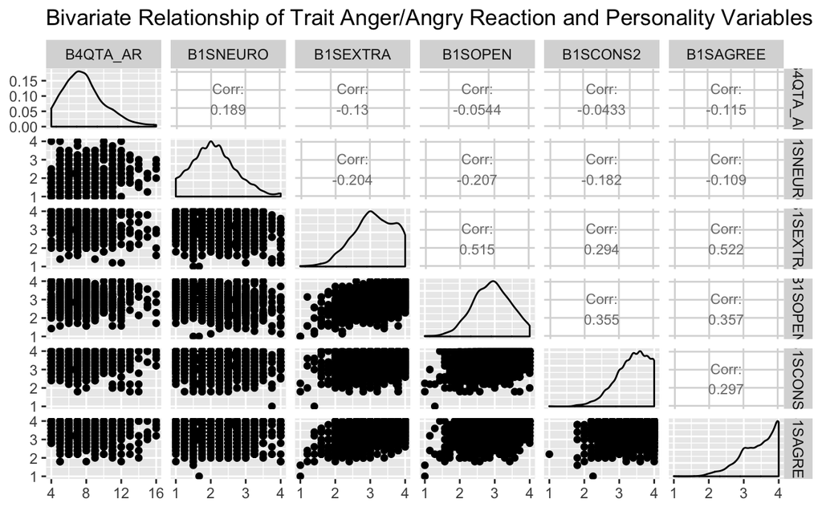

```r
scatterplot <- ggpairs(analyze,
                       columns = c("B4QTA_AR", "B1SNEURO", "B1SEXTRA", "B1SOPEN", "B1SCONS2", "B1SAGREE"),
                       upper = list(continuous = wrap("cor", size=3)),
        title = "Bivariate Relationship of Trait Anger/Angry Reaction and Personality Variables")
print(scatterplot, progress=FALSE )
```

## Hone in on Angry Reaction and one of the personality variables

I am going to select Agreeableness, first I will subset to include only cases with complete data on my two variables of interest

```r
myvars <- analyze %>%
  select(B4QTA_AR, B1SAGREE) %>%
  na.omit()
```

## Descriptive Statistics

### Angry Reaction

```r
summary_stats(myvars$B4QTA_AR)
```

[output not shown]

### Agreeableness

```r
summary_stats(myvars$B1SAGREE)
```

```
                        Univariate Analysis

 N                      627.00      Variance                 0.27
 Missing                  0.00      Std Deviation            0.52
 Mean                     3.42      Range                    2.20
 Median                   3.60      Interquartile Range      0.80
 Mode                     4.00      Uncorrected SS        7488.40
 Trimmed Mean             3.45      Corrected SS           167.33
 Skewness                -0.75      Coeff Variation         15.13
 Kurtosis                -0.16      Std Error Mean           0.02

                              Quantiles

              Quantile                            Value

             Max                                   4.00
             99%                                   4.00
             95%                                   4.00
             90%                                   4.00
             Q3                                    3.80
             Median                                3.60
             Q1                                    3.00
             10%                                   2.60
             5%                                    2.40
             1%                                    2.05
             Min                                   1.80

                            Extreme Values

                Low                                High

  Obs                        Value       Obs                        Value
  28                          1.8         4                           4
  124                         1.8        10                           4
  173                         1.8        21                           4
  452                         1.8        22                           4
  198                          2         24                           4
```

## Set hypotheses

I am interested in assessing the relationship between Agreeableness and Angry Reaction. In this case, I am not particularly interested in a significance test for the intercept, it’s the slope that is of interest. I will state a null and alternative hypothesis for the slope.

My null hypothesis: B1 (the regression slope) is equal to 0 My alterntive hypothesis: B1 is not equal to 0

## Set alpha and obtain the critical value of t

I am going to set alpha to .05, and use a 2 tailed test. For a SLR, the df equals n - 1 - # of predictors, so n-2, or 627 - 2 = 625 for my case.

```r
qt(c(.025, .975), df=625)
```

```
[1] -1.963767  1.963767
```

The critical value of t for this model is 1.964. If t-star is either greater than 1.964 or less than -1.964 then I will reject the null hypothesis.

## Center Agreeableness at the mean and then fit the SLR

From the descriptive statistics above, we see that Agreeableness ranges from 1.80 to 4, so 0 isn’t an observed value for this variable. Since the intercept of our SLR will represent the predicted value of y, when x equals 0, we should create a meaningful value of 0 for x. To do this, I will center at the mean.

```r
myvars <- myvars %>%
  mutate(B1SAGREE_m = B1SAGREE - mean(B1SAGREE))
my_model <- lm(B4QTA_AR ~ B1SAGREE_m, data = myvars)

ols_regress(my_model)
```

```
                        Model Summary
--------------------------------------------------------------
R                       0.115       RMSE                2.380
R-Squared               0.013       Coef. Var          30.715
Adj. R-Squared          0.012       MSE                 5.663
Pred R-Squared          0.007       MAE                 1.858
--------------------------------------------------------------
 RMSE: Root Mean Square Error
 MSE: Mean Square Error
 MAE: Mean Absolute Error

                               ANOVA
--------------------------------------------------------------------
                Sum of
               Squares         DF    Mean Square      F        Sig.
--------------------------------------------------------------------
Regression      47.484          1         47.484    8.385    0.0039
Residual      3539.239        625          5.663
Total         3586.724        626
--------------------------------------------------------------------

                                  Parameter Estimates
----------------------------------------------------------------------------------------
      model      Beta    Std. Error    Std. Beta      t        Sig      lower     upper
----------------------------------------------------------------------------------------
(Intercept)     7.748         0.095                 81.523    0.000     7.561     7.934
 B1SAGREE_m    -0.533         0.184       -0.115    -2.896    0.004    -0.894    -0.171
----------------------------------------------------------------------------------------
```

The intercept is 7.748, this is the predicted Angry Reaction score for individuals with an average level of Agreeableness. The slope is -0.533, this is the expected change in Angry Reaction for a one unit increase in Agreeableness.

The estimate of the slope divided by the associated standard error gives t-star, that is t-star = -0.533/.184 = -2.896. This means that our estimate of the slope is 2.896 standard errors away from the asserted null hypothesis (0). If the null hypothesis were true, we would expect about 95% of the random samples to produce an estimate of the slope that is within 1.96 standard errors of 0. Therefore it is highly unlikely that the null hypothesis is true given this estimate of the slope. In fact, the p-value is less than .004, which provides the probability that we would obtain a t-star of this magnitude or larger if the null hypothesis were true. Therefore, we reject the null hypothesis.

The 95% CI is -.894 to -.171. Based on the sampling distribution, we expect that 95% of the 95% CI’s that we would construct across many, many random samples would contain the population slope. We can think of the 95% CI as giving us a range of plausible values for the parameter estimate and showing us the precision of our estimate. The fact that 0 is not inside the 95% CI corresponds with our t-test, that is, 0 is not likely to be a plausile value for the slope.

## Calculate predicted scores

I will request the predicted y when x is 1 SD below the mean, at the mean, and 1 SD above the mean in the sample. I will ask for both a 95% confidence interval and a 95% prediction interval around these predicted values.

```r
# pick a few prototypical values
predgrid <- data_grid(myvars, B1SAGREE_m = c(-.52, 0, .52))
predict(my_model, predgrid, interval = "confidence", level = .95)
```

```
       fit      lwr      upr
1 8.024534 7.759736 8.289331
2 7.747528 7.560902 7.934153
3 7.470522 7.205724 7.735320
```

```r
predict(my_model, predgrid, interval = "prediction", level = .95)
```

```
       fit      lwr      upr
1 8.024534 3.343940 12.70513
2 7.747528 3.070705 12.42435
3 7.470522 2.789928 12.15112
```

Notice that the 95% CI for the prediction interval is much wider to account for the fact that this is a prediction interval for a single new y – not for the mean of y. Also notice that the fitted value and 95% confidence interval for x = 0 is the same as the estimate of the intercept and the 95% CI for the intercept in the regression model. These are two ways of testing the same quantity.

## Create scatterplot of Agreeableness and Angry Reaction with fitted model

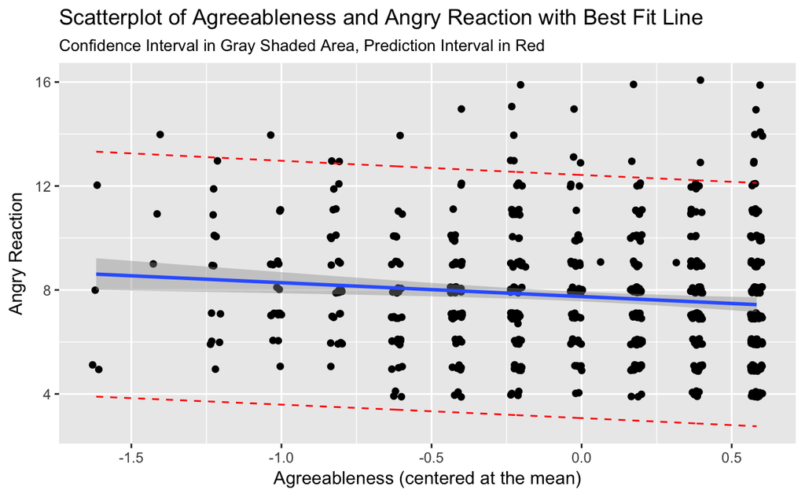

```r
# first get the prediction intervals for all cases in the dataset
temp_var <- predict(my_model, myvars, interval="prediction")
myvars_new <- cbind(temp_var, myvars)
ggplot(myvars_new, aes(x = B1SAGREE_m, y =B4QTA_AR)) +
  geom_jitter() +
  geom_smooth(method = "lm", se = TRUE) +
  geom_line(aes(y=lwr), color = "red", linetype = "dashed") +
  geom_line(aes(y=upr), color = "red", linetype = "dashed") +
  labs(title = "Scatterplot of Agreeableness and Angry Reaction with Best Fit Line",
       subtitle = "Confidence Interval in Gray Shaded Area, Prediction Interval in Red",
       x = "Agreeableness (centered at the mean)", y = "Angry Reaction")
```

## Create graph of residuals

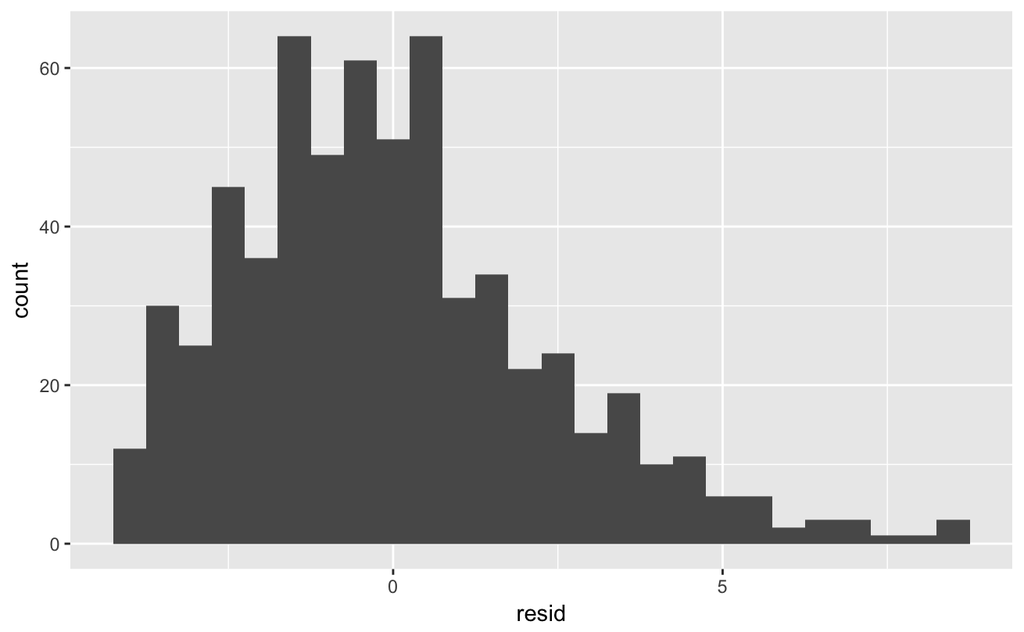

```r
myvars <- myvars %>%
  add_residuals(my_model)

ggplot(myvars, aes(x = resid)) + geom_histogram(binwidth = .5)
```